# GSS Analysis about opinions on sexual behaviour in US from 1972 to 2016

## Some basic regressions with plenty of problems

```r
lm1<-lm(homosex ~ conclerg + female_pct + age +
               partyid+married_pct+ba_pct+log(realinc)+white_pct+pray
        +attend+log(size)+fund_pct, data=by.year.ts)

summary(lm1, scientific=FALSE)
```

```
##
## Call:
## lm(formula = homosex ~ conclerg + female_pct + age + partyid +
##     married_pct + ba_pct + log(realinc) + white_pct + pray +
##     attend + log(size) + fund_pct, data = by.year.ts)
##
## Residuals:
##       Min        1Q    Median        3Q       Max
## -0.082361 -0.026721 -0.001631  0.022001  0.077995
##
## Coefficients:
##               Estimate Std. Error t value Pr(>|t|)
## (Intercept)  19.281902   6.909874   2.790   0.0210 *
## conclerg      0.316477   0.470787   0.672   0.5183
## female_pct   -0.036348   0.023374  -1.555   0.1543
## age          -0.071537   0.030865  -2.318   0.0457 *
## partyid      -0.541519   0.311235  -1.740   0.1159
## married_pct  -0.014995   0.014613  -1.026   0.3316
## ba_pct       -0.023005   0.009180  -2.506   0.0335 *
## log(realinc) -0.092956   0.430446  -0.216   0.8338
## white_pct    -0.011535   0.009383  -1.229   0.2501
## pray         -1.127900   0.498009  -2.265   0.0498 *
## attend        0.250951   0.201065   1.248   0.2435
## log(size)    -0.535092   0.291333  -1.837   0.0994 .
## fund_pct      0.037989   0.014332   2.651   0.0264 *
## ---
## Signif. codes:  0 '***' 0.001 '**' 0.01 '*' 0.05 '.' 0.1 ' ' 1
##
## Residual standard error: 0.06878 on 9 degrees of freedom
##   (9 observations deleted due to missingness)
## Multiple R-squared:  0.9867, Adjusted R-squared:  0.9689
## F-statistic: 55.44 on 12 and 9 DF,  p-value: 0.0000006261
```

```r
bptest(lm1) #no reason to reject null hyppthesis
```

```
##
##  studentized Breusch-Pagan test
##
## data:  lm1
## BP = 12.531, df = 12, p-value = 0.4041
```

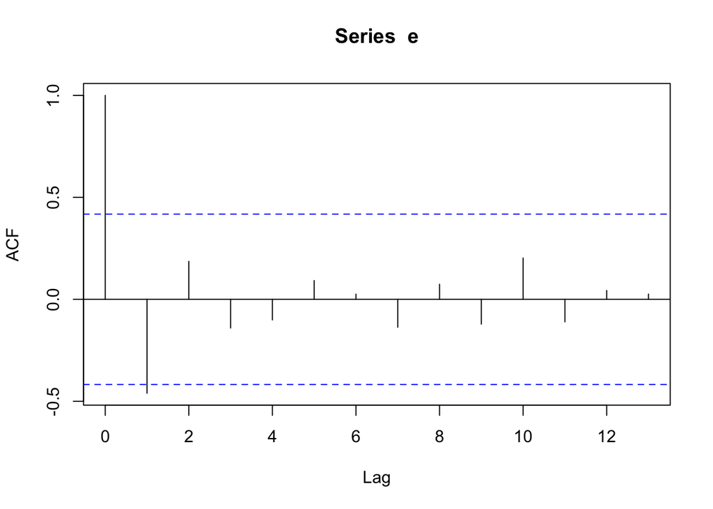

```r
# look for autocorrelation in errors
e <- lm1$resid
acf(e)
```

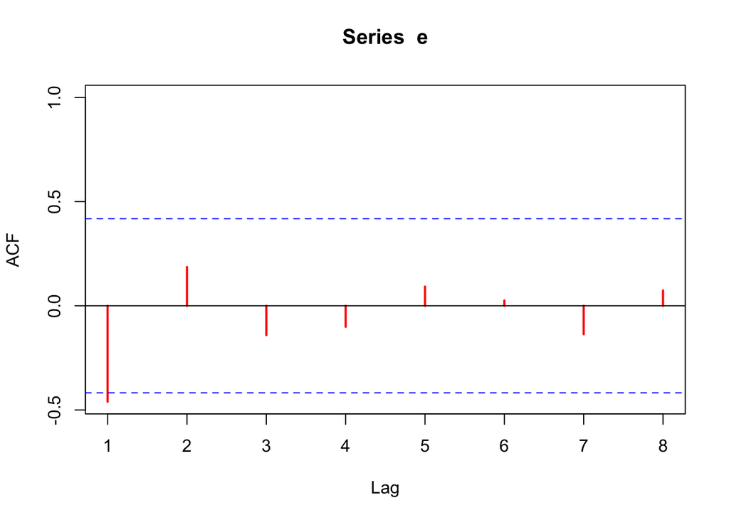

```r
acf(e, xlim = c(1,8), col = "red", lwd = 2) # can also customize acf output
```

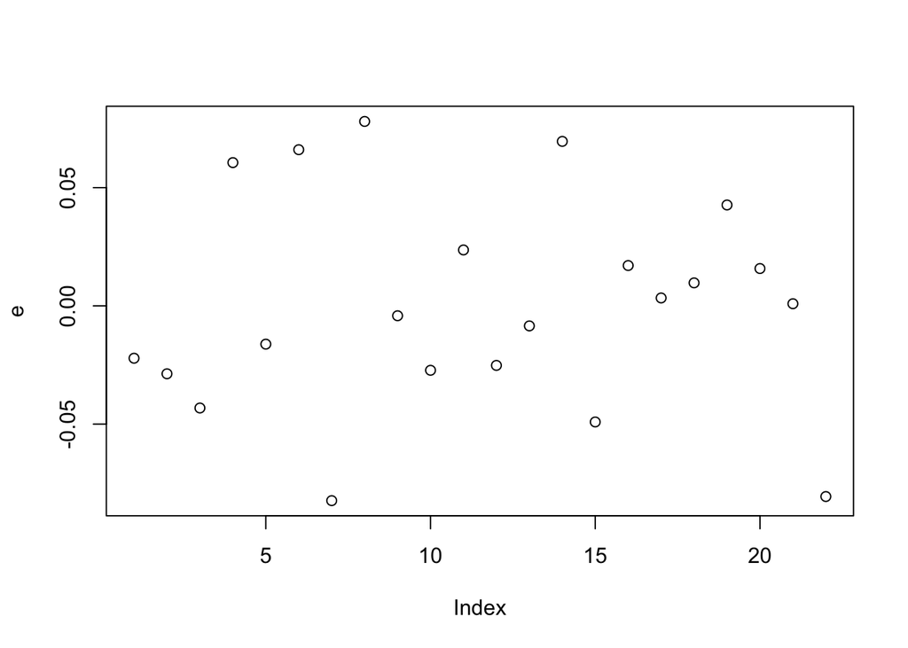

```r
plot(e) # plot residuals over time
```

```r
dwtest(lm1) # Durbin-Watson test
```

```
##
##  Durbin-Watson test
##
## data:  lm1
## DW = 2.757, p-value = 0.7671
## alternative hypothesis: true autocorrelation is greater than 0
```

```r
bgtest(lm1) # Breusch-Godfrey test
```

```
##
##  Breusch-Godfrey test for serial correlation of order up to 1
##
## data:  lm1
## LM test = 9.257, df = 1, p-value = 0.002346
```

```r
durbinWatsonTest(lm1, max.lag=2) # Durbin-Watson with more lags
```

```
##  lag Autocorrelation D-W Statistic p-value
##    1      -0.4605984      2.757038   0.432
##    2       0.1860485      1.444363   0.252
##  Alternative hypothesis: rho[lag] != 0
```

There is indication that there is autocorrelation(1). It also probably fails the vif and is also a unit root process.

## More problems but this time with a year trend

```r
# include year trend
lm2 <- update(lm1, ~ .  + year)
summary(lm2)
```

```
##
## Call:
## lm(formula = homosex ~ conclerg + female_pct + age + partyid +
##     married_pct + ba_pct + log(realinc) + white_pct + pray +
##     attend + log(size) + fund_pct + year, data = by.year.ts)
##
## Residuals:
##       Min        1Q    Median        3Q       Max
## -0.067495 -0.020510 -0.001051  0.020328  0.051605
##
## Coefficients:
##                Estimate Std. Error t value Pr(>|t|)
## (Intercept)  222.658327  64.169751   3.470  0.00844 **
## conclerg      -0.044221   0.350810  -0.126  0.90280
## female_pct    -0.019333   0.017328  -1.116  0.29693
## age            0.163854   0.077188   2.123  0.06654 .
## partyid        0.746919   0.460948   1.620  0.14381
## married_pct    0.045613   0.021674   2.105  0.06845 .
## ba_pct         0.057358   0.026099   2.198  0.05920 .
## log(realinc)  -0.018809   0.304399  -0.062  0.95225
## white_pct     -0.017685   0.006893  -2.566  0.03336 *
## pray          -0.081085   0.481420  -0.168  0.87043
## attend         0.312789   0.143098   2.186  0.06031 .
## log(size)     -0.914574   0.237592  -3.849  0.00488 **
## fund_pct      -0.019776   0.020794  -0.951  0.36942
## year          -0.113225   0.035622  -3.179  0.01303 *
## ---
## Signif. codes:  0 '***' 0.001 '**' 0.01 '*' 0.05 '.' 0.1 ' ' 1
##
## Residual standard error: 0.0485 on 8 degrees of freedom
##   (9 observations deleted due to missingness)
## Multiple R-squared:  0.9941, Adjusted R-squared:  0.9845
## F-statistic: 103.7 on 13 and 8 DF,  p-value: 0.0000001934
```

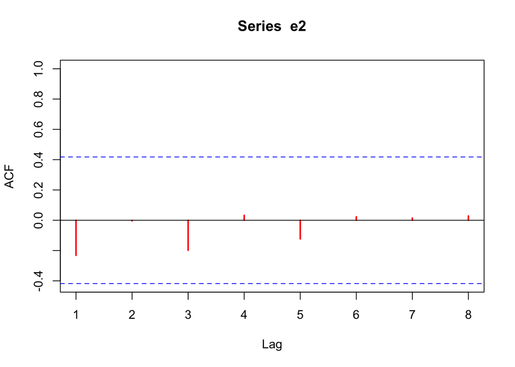

```r
# look for autocorrelation
e2 <- lm2$resid
acf(e2, xlim = c(1,8), col = "red", lwd = 2)
```

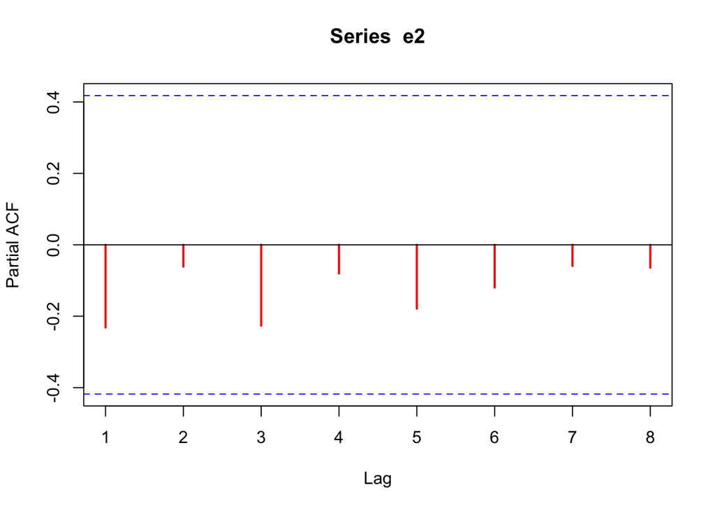

```r
pacf(e2, xlim = c(1,8), col = "red", lwd = 2)
```

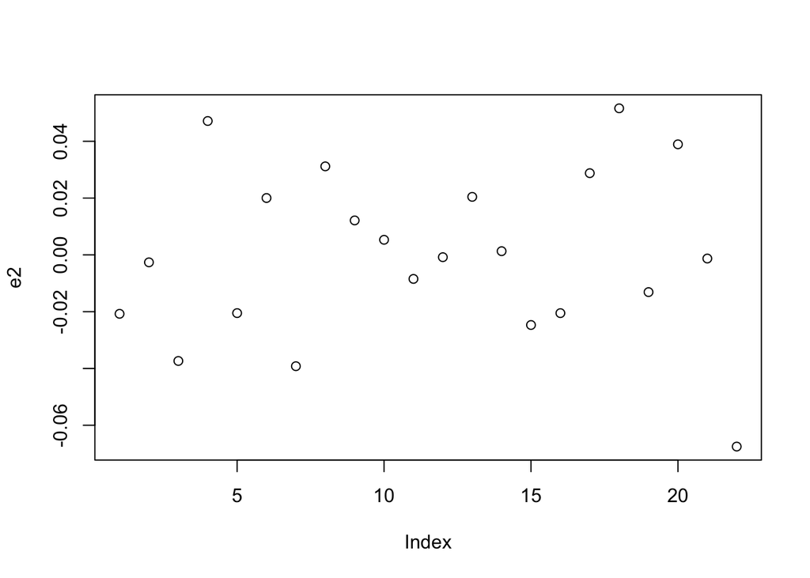

```r
plot(e2)
```

```r
dwtest(lm2)
```

```
##
##  Durbin-Watson test
##
## data:  lm2
## DW = 2.1983, p-value = 0.2816
## alternative hypothesis: true autocorrelation is greater than 0
```

```r
bgtest(lm2)
```

```
##
##  Breusch-Godfrey test for serial correlation of order up to 1
##
## data:  lm2
## LM test = 4.6897, df = 1, p-value = 0.03034
```

```r
#Breusch-Godfrey tests similarly suggests presence of autocorrelation.
durbinWatsonTest(lm2, max.lag=3)
```

```
##  lag Autocorrelation D-W Statistic p-value
##    1    -0.231642997      2.198301   0.542
##    2    -0.004294852      1.743149   0.604
##    3    -0.198175793      1.976209   0.800
##  Alternative hypothesis: rho[lag] != 0
```

```r
vif(lm2)
```

```
##     conclerg   female_pct          age      partyid  married_pct
##     5.500546     4.242056   106.530432    29.405893    52.744287
##       ba_pct log(realinc)    white_pct         pray       attend
##   323.264456     6.051239    12.490644    10.602532    11.644127
##    log(size)     fund_pct         year
##     4.824042    64.619461  1249.304360
```

```r
#VIF indicates issues with married pct, ba_pct, year_pct, age, fund_pct, white_pct.
```

## Finally proceeds to first-difference the data to get rid of unit root process

```r
by.yearFD <- mutate(data.frame(by.year.ts),
                    homosex=firstD(homosex),
                    conclerg = firstD(conclerg),
                    female_pct = firstD(female_pct),
                    age = firstD(age),
                    partyid=firstD(partyid),
                    married_pct=firstD(married_pct),
                    ba_pct=firstD(ba_pct),
                    white_pct=firstD(white_pct),
                    pray = firstD(pray),
                    attend=firstD(attend),
                    size=firstD(size),
                    fund_pct=firstD(fund_pct),
                    year = year)

lm3<-lm(homosex ~ conclerg + female_pct + age +
              partyid+married_pct+ba_pct+log(realinc)+white_pct+pray
            +attend+size+fund_pct+year, data=by.yearFD)
summary(lm3)
```

```
##
## Call:
## lm(formula = homosex ~ conclerg + female_pct + age + partyid +
##     married_pct + ba_pct + log(realinc) + white_pct + pray +
##     attend + size + fund_pct + year, data = by.yearFD)
##
## Residuals:
##       Min        1Q    Median        3Q       Max
## -0.064743 -0.024379  0.007706  0.017260  0.059572
##
## Coefficients:
##                Estimate Std. Error t value Pr(>|t|)
## (Intercept)  11.9125889  3.2826861   3.629  0.00841 **
## conclerg      0.0837055  0.3080292   0.272  0.79366
## female_pct   -0.0243473  0.0127210  -1.914  0.09719 .
## age           0.1129141  0.0577832   1.954  0.09161 .
## partyid       0.7505749  0.3365356   2.230  0.06094 .
## married_pct   0.0293916  0.0175483   1.675  0.13786
## ba_pct        0.0290986  0.0199729   1.457  0.18849
## log(realinc) -0.1735154  0.3357915  -0.517  0.62126
## white_pct    -0.0176232  0.0069845  -2.523  0.03962 *
## pray         -0.1034622  0.3964738  -0.261  0.80164
## attend        0.4321778  0.1573939   2.746  0.02868 *
## size         -0.0025459  0.0005984  -4.255  0.00377 **
## fund_pct     -0.0260263  0.0162037  -1.606  0.15227
## year         -0.0051274  0.0022224  -2.307  0.05441 .
## ---
## Signif. codes:  0 '***' 0.001 '**' 0.01 '*' 0.05 '.' 0.1 ' ' 1
##
## Residual standard error: 0.05702 on 7 degrees of freedom
##   (10 observations deleted due to missingness)
## Multiple R-squared:  0.8434, Adjusted R-squared:  0.5526
## F-statistic:   2.9 on 13 and 7 DF,  p-value: 0.08165
```

```r
vif(lm3)
```

```
##     conclerg   female_pct          age      partyid  married_pct
##     3.120123     2.628485     8.119691    10.173278     6.014541
##       ba_pct log(realinc)    white_pct         pray       attend
##     8.809309     5.292649    10.132702     5.467488     2.019993
##         size     fund_pct         year
##     6.451528    15.137543     3.202476
```

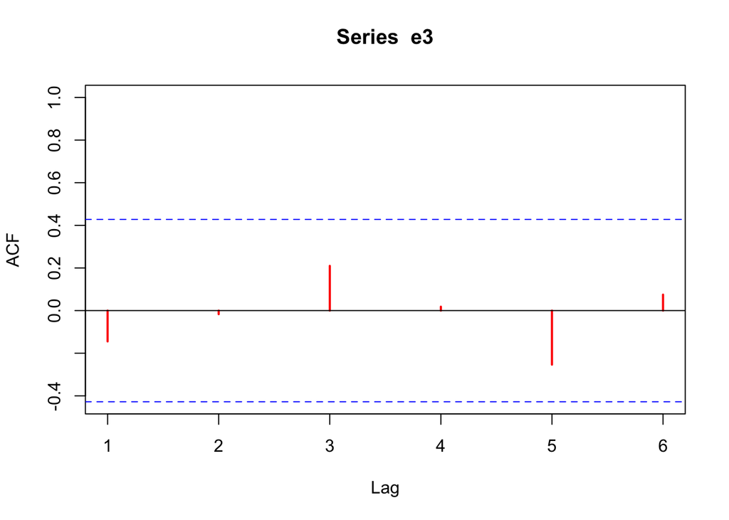

```r
e3 <- lm3$resid
acf(e3, xlim = c(1,6), col = "red", lwd = 2)
```

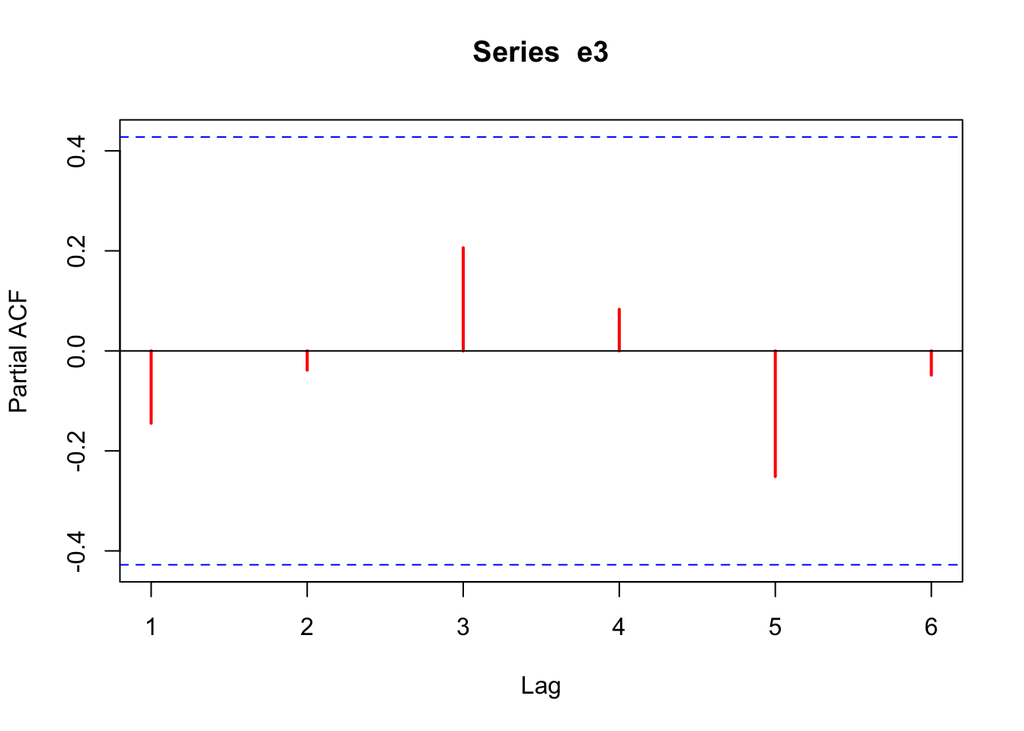

```r
pacf(e3, xlim = c(1,6), col = "red", lwd = 2)
```

```r
auto.arima(e3, trace=TRUE)
```

```
##
##  ARIMA(2,0,2) with non-zero mean : Inf
##  ARIMA(0,0,0) with non-zero mean : -79.11517
##  ARIMA(1,0,0) with non-zero mean : -76.82531
##  ARIMA(0,0,1) with non-zero mean : -76.81513
##  ARIMA(0,0,0) with zero mean     : -81.57131
##  ARIMA(1,0,1) with non-zero mean : -73.7418
##
##  Best model: ARIMA(0,0,0) with zero mean
```

```
## Series: e3
## ARIMA(0,0,0) with zero mean
##
## sigma^2 estimated as 0.001084:  log likelihood=41.89
## AIC=-81.78   AICc=-81.57   BIC=-80.74
```

```r
dwtest(lm3)
```

```
##
##  Durbin-Watson test
##
## data:  lm3
## DW = 2.2196, p-value = 0.8803
## alternative hypothesis: true autocorrelation is greater than 0
```

```r
bgtest(lm3,order=3)
```

```
##
##  Breusch-Godfrey test for serial correlation of order up to 3
##
## data:  lm3
## LM test = 4.6088, df = 3, p-value = 0.2028
```

```r
adfTest(by.yearFD[,"homosex"], lags = 3, type="ct")
```

```
##
## Title:
##  Augmented Dickey-Fuller Test
##
## Test Results:
##   PARAMETER:
##     Lag Order: 3
##   STATISTIC:
##     Dickey-Fuller: -2.8404
##   P VALUE:
##     0.2492
##
## Description:
##  Mon Dec 31 19:22:51 2018 by user:
```

```r
summary(lm3)
```

```
##
## Call:
## lm(formula = homosex ~ conclerg + female_pct + age + partyid +
##     married_pct + ba_pct + log(realinc) + white_pct + pray +
##     attend + size + fund_pct + year, data = by.yearFD)
##
## Residuals:
##       Min        1Q    Median        3Q       Max
## -0.064743 -0.024379  0.007706  0.017260  0.059572
##
## Coefficients:
##                Estimate Std. Error t value Pr(>|t|)
## (Intercept)  11.9125889  3.2826861   3.629  0.00841 **
## conclerg      0.0837055  0.3080292   0.272  0.79366
## female_pct   -0.0243473  0.0127210  -1.914  0.09719 .
## age           0.1129141  0.0577832   1.954  0.09161 .
## partyid       0.7505749  0.3365356   2.230  0.06094 .
## married_pct   0.0293916  0.0175483   1.675  0.13786
## ba_pct        0.0290986  0.0199729   1.457  0.18849
## log(realinc) -0.1735154  0.3357915  -0.517  0.62126
## white_pct    -0.0176232  0.0069845  -2.523  0.03962 *
## pray         -0.1034622  0.3964738  -0.261  0.80164
## attend        0.4321778  0.1573939   2.746  0.02868 *
## size         -0.0025459  0.0005984  -4.255  0.00377 **
## fund_pct     -0.0260263  0.0162037  -1.606  0.15227
## year         -0.0051274  0.0022224  -2.307  0.05441 .
## ---
## Signif. codes:  0 '***' 0.001 '**' 0.01 '*' 0.05 '.' 0.1 ' ' 1
##
## Residual standard error: 0.05702 on 7 degrees of freedom
##   (10 observations deleted due to missingness)
## Multiple R-squared:  0.8434, Adjusted R-squared:  0.5526
## F-statistic:   2.9 on 13 and 7 DF,  p-value: 0.08165
```

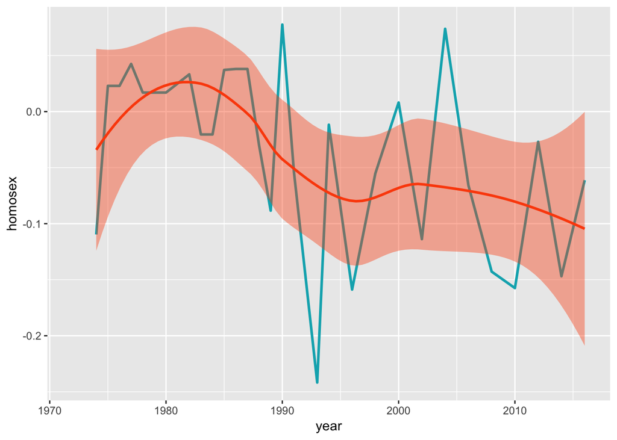

```r
#Base plots
p <- ggplot(data = by.yearFD, aes(x = year, y = homosex)) +
  geom_line(color = "#00AFBB", size = 1)

p + stat_smooth(
  color = "#FC4E07", fill = "#FC4E07",
  method = "loess"
)
```

Auto.arima did not suggest any alterations which is a little strange.

Just getting started with this and there are probably alot of statistical errors in this which require further addressing. Let me know at email.